# Homework 3

DATS 6101 · Fall 2026

Sam Nicholes

2026-09-27

https://www.smajhi.com/DATS-6101/homework/hw3.html

```r
library(nycflights13)
library(tidyverse)
data(flights)

d <- flights[complete.cases(flights), ] # data set of complete rows stored as d
```

# Part 1 · A payout table (12 points)

## (1a) The payout distribution, and its expectation two ways

```r
# Build payout for every flight
flights <- flights %>%
  dplyr::mutate(
    payout = dplyr::case_when(
      is.na(dep_delay) ~ 400,
      !is.na(dep_delay) & is.na(arr_delay) ~ 200,
      arr_delay > 180 ~ 200,
      arr_delay > 60 & arr_delay <= 180 ~ 50,
      TRUE ~ 0
    )
  )

# flights$payout # check column values


# Report the probability of each payout value
pCanceled <- mean(is.na(flights$dep_delay))
pCanceled
```

```
## [1] 0.02451184
```

```r
pDiverted <- mean(!is.na(flights$dep_delay) & is.na(flights$arr_delay))
pDiverted
```

```
## [1] 0.003488966
```

```r
p180Late <- sum(flights$arr_delay > 180, na.rm = TRUE) / nrow(flights)
p180Late
```

```
## [1] 0.01141115
```

```r
pLate <- sum(60 < flights$arr_delay & flights$arr_delay <= 180, na.rm = TRUE) / nrow(flights)
pLate
```

```
## [1] 0.07110364
```

```r
# Compute E[X] two ways - outputs must agree:

# 1) ... from the table

cashCanceled <- 400
cashDiverted <- 200
cash180Late <- 200
cashLate <- 50
cashOther <- 0 # cancels out

EPayout_theoretical <- (cashCanceled * pCanceled) + (cashDiverted * pDiverted) + (cash180Late * p180Late) + (cashLate * pLate)
EPayout_theoretical
```

```
## [1] 16.33994
```

```r
# 2)  ... using mean() of the payout column

EPayout_actual <- mean(flights$payout)
EPayout_actual
```

```
## [1] 16.33994
```

```r
isTRUE(all.equal(EPayout_theoretical, EPayout_actual))
```

```
## [1] TRUE
```

```r
EPayout_theoretical == EPayout_actual # Floating point error
```

```
## [1] FALSE
```

## (1b) Where the expectation sits

The share of expected payouts from cancellations make up the tail of the distribution, and the expected overall payout sits just past the bulk of data (flights with $0 or $50 payouts) toward the skewed tail of the distribution.

```r
pCanceled # share of flights that are canceled
```

```
## [1] 0.02451184
```

```r
cancelContribtuion <- cashCanceled * pCanceled # payout per flight due to cancellations
cancelShareOfPayout <- cancelContribtuion / EPayout_actual
cancelShareOfPayout
```

```
## [1] 0.6000472
```

## (1c) A fair fee, and a 900-flight day

A fair fee is the Expectation of the payout, $16.34, with the expected cost for 900 flights per day being $14,705.95. This Expectation is a linear model, meaning independence/dependence of flights is irrelevant.

```r
E900 <- 900 * EPayout_actual
E900
```

```
## [1] 14705.95
```

# Part 2 · Sums are free, variances are not (16 points)

## (2a) Daily late counts by airport, and the total

```r
d <- d %>% dplyr::mutate(date = lubridate::make_date(year, month, day))

# Late arrival counts for each day and origin ----------------------------------
d_late_daily_origin <- d %>%
  dplyr::group_by(origin, date) %>%
  dplyr::filter(arr_delay > 15) %>%
  dplyr::summarise(n = n())


# 1) Per-airport daily counts --------------------------------------------------
# Per airport daily  - JFK
jfk_daily_count <- d_late_daily_origin$n[d_late_daily_origin$origin == "JFK"]
jfk_mean <- mean(jfk_daily_count) # average across days
jfk_var <- var(jfk_daily_count) # variance across days
sqrt(jfk_var)
```

```
## [1] 45.72694
```

```r
# Per airport daily  - EWR
ewr_daily_count <- d_late_daily_origin$n[d_late_daily_origin$origin == "EWR"]
ewr_mean <- mean(ewr_daily_count) # average across days
ewr_var <- var(ewr_daily_count) # variance across days
sqrt(ewr_var)
```

```
## [1] 49.40346
```

```r
# Per airport daily  - LGA
lga_daily_count <- d_late_daily_origin$n[d_late_daily_origin$origin == "LGA"]
lga_mean <- mean(lga_daily_count) # average across days
lga_var <- var(lga_daily_count) # variance across days
sqrt(lga_var)
```

```
## [1] 46.34999
```

```r
# 2) Daily total across all three airports --------------------------------------
# Daily total of the three airports: JFK, EWR, LGA
d_late_daily_total <- d_late_daily_origin %>%
  dplyr::group_by(date) %>%
  dplyr::summarise(total_n = sum(n))

d_late_daily_total_mean <- mean(d_late_daily_total$total_n)
d_late_daily_total_var <- var(d_late_daily_total$total_n) # by how much the aggregated airports vary on a daily basis
sqrt(d_late_daily_total_var) # SD - how much the aggregated airports vary on a daily basis, # of flights
```

```
## [1] 129.6938
```

```r
# 3) Does the mean of the total equal the sum of the three means? --------------
isTRUE(all.equal((jfk_mean + ewr_mean + lga_mean), d_late_daily_total_mean))
```

```
## [1] TRUE
```

```r
# 4) Variance of the total compared to the sum of the three variances ----------
d_late_daily_total_var / (jfk_var + ewr_var + lga_var)
```

```
## [1] 2.518046
```

```r
# Ratio to describe linear relationship:
#   ratio ~ 1, covariance = 0
#   ratio > 1, covariance > 0, data vary positively
#   ratio < 1, covariance < 0, data vary negatively
```

## (2b) The covariance terms

```r
# Compute the 3 covariances between airports:
jfk_n <- d_late_daily_origin$n[d_late_daily_origin$origin == "JFK"]

length(jfk_n)
```

```
## [1] 365
```

```r
ewr_n <- d_late_daily_origin$n[d_late_daily_origin$origin == "EWR"]

lga_n <- d_late_daily_origin$n[d_late_daily_origin$origin == "LGA"]

cov_jfk_ewr <- cov(jfk_n, ewr_n)
cov_jfk_lga <- cov(jfk_n, lga_n)
cov_ewr_lga <- cov(ewr_n, lga_n)

# Compute 3 correlations between airports:
cor_jfk_ewr <- cor(jfk_n, ewr_n)
cor_jfk_lga <- cor(jfk_n, lga_n)
cor_ewr_lga <- cor(ewr_n, lga_n)

var_total <- (jfk_var + ewr_var + lga_var) + 2*(cov_jfk_ewr + cov_jfk_lga + cov_ewr_lga)
var_total
```

```
## [1] 16820.49
```

```r
isTRUE(all.equal(d_late_daily_total_var, var_total))
```

```
## [1] TRUE
```

## (2c) For the planner

The airports at least share airspace, weather, and the same NYC population which drives the covariance and correlation to be positive - the airports will have similar problems with delays. Since the planner is only adding the variances, but not the covariances the planner will understate the day-to-day change.

HW Note: “The population. In Parts 3 to 6, treat d$arr_delay as the entire population. Its mean is μ and its standard deviation is σ. sd() divides by n−1n−1 rather than by the population size; with 327,346 rows the difference is in the fifth significant digit, so either is fine.”

# Part 3 · A population you can see (18 points)

## (3a) mu and sigma

```r
population_flights <- d$arr_delay
mu <- mean(population_flights) # population mean
sigma <- sd(population_flights) # population sd
mu
```

```
## [1] 6.895377
```

```r
sigma
```

```
## [1] 44.63329
```

## (3b) The sampling distribution at four sample sizes

Standard error takes into account how the data are spread, but in terms of the center or the direction of skewness it is independent.

```r
set.seed(6101)

# draw a sample of n, 5000 times and calculate a mean for each of the 5000 samples: result is 5000 means for each sampling
means25 <- colMeans(replicate(5000, sample(population_flights, 25, replace = TRUE)))
length(means25)
```

```
## [1] 5000
```

```r
means100 <- colMeans(replicate(5000, sample(population_flights, 100, replace = TRUE)))
length(means100)
```

```
## [1] 5000
```

```r
means400 <- colMeans(replicate(5000, sample(population_flights, 400, replace = TRUE)))
length(means400)
```

```
## [1] 5000
```

```r
means1600 <- colMeans(replicate(5000, sample(population_flights, 1600, replace = TRUE)))
length(means1600)
```

```
## [1] 5000
```

```r
# standard deviation and standard error
sd(means25)
```

```
## [1] 9.141913
```

```r
sigma / sqrt(25)
```

```
## [1] 8.926658
```

```r
sd(means100)
```

```
## [1] 4.440668
```

```r
sigma / sqrt(100)
```

```
## [1] 4.463329
```

```r
sd(means400)
```

```
## [1] 2.267884
```

```r
sigma / sqrt(400)
```

```
## [1] 2.231665
```

```r
sd(means1600)
```

```
## [1] 1.119698
```

```r
sigma / sqrt(1600)
```

```
## [1] 1.115832
```

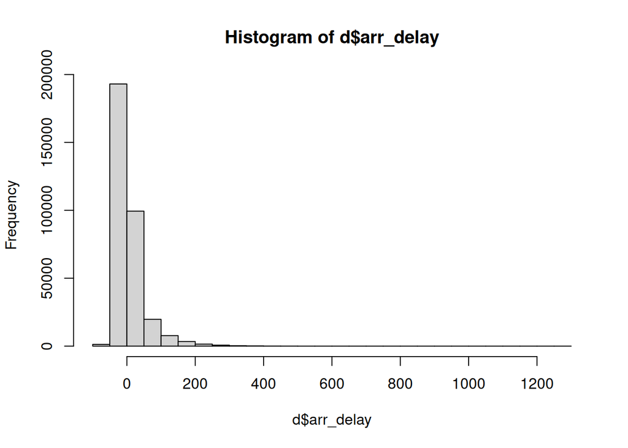

```r
hist(d$arr_delay) # right skewed distribution
```

## (3c) One sample of 400: the SD sentence and the SE sentence

```r
set.seed(6101)
mean(sample(population_flights, 400, replace = TRUE))
```

```
## [1] 5.115
```

```r
sd(sample(population_flights, 400, replace = TRUE))
```

```
## [1] 47.62109
```

```r
sigma/sqrt(400)
```

```
## [1] 2.231665
```

## (3d) How many flights

```r
# SE = 1 minute
n_1min <- (sigma / 1)^2
n_1min
```

```
## [1] 1992.131
```

```r
# SE = 0.5 minute
n_half <- (sigma / 0.5)^2
n_half
```

```
## [1] 7968.523
```

# Part 4 · When n is not n (24 points)

## (4a) Sixteen days, 2,000 times

```r
set.seed(6101)
by_day <- split(d$arr_delay, d$date)

sampleDays <- replicate(2000, unlist(by_day[sample(names(by_day), 16)]), simplify = FALSE)
n_per_replicate <- sapply(sampleDays, length)
means_per_replicate <- sapply(sampleDays, mean)

mean_of_n_replicates <- mean(n_per_replicate)
sd(means_per_replicate)
```

```
## [1] 4.116826
```

```r
se_real <- sd(means_per_replicate)

se_estimate_replicates <- sigma / sqrt(mean_of_n_replicates)
se_estimate_replicates
```

```
## [1] 0.3725565
```

## (4b) What the formula says, and random flights

```r
sampleFlights <- replicate(2000, mean(sample(population_flights, round(mean_of_n_replicates), replace = TRUE)))
se_empirical_flights <- sd(sampleFlights)
se_empirical_flights
```

```
## [1] 0.360517
```

```r
se_ratio <- se_real / se_estimate_replicates
se_ratio # actual SE is 11x larger than estimate. SE estimate is assuming independence. SE actual is results from clustering from sampling scheme (sampling days instead of flights)
```

```
## [1] 11.05021
```

## (4c) The effective sample size

```r
n_effective <- (sigma / se_real)^2
n_effective
```

```
## [1] 117.5419
```

```r
fraction <- n_effective / mean_of_n_replicates
fraction
```

```
## [1] 0.008189533
```

```r
# Analyst's sampling scheme results in a small sample size that is independent and random. IE small sample size of independent, random flights results in a large SE
```

## (4d) The days as the units

The SE is similar to what was calculated in part a, meaning that days are still treated as the unit.

```r
daily_means <- sapply(by_day, mean)
sd_daily_means <- sd(daily_means)
sd_daily_means
```

```
## [1] 17.28193
```

```r
se_by_day_unit <- sd_daily_means / sqrt(16)
se_by_day_unit
```

```
## [1] 4.320483
```

## (4e) Which step failed

Calculating the SE requires independent observations at the level of the unit of analysis (step 2), in this case, the flights. The sampling scheme developed by the analyst does not allow independence among flights as days were randomly sampled with all the flights of a given day. This results in clustering of flights as they’ll all share underlying characteristics. The result of this clustering is positive covariances among flights since they share certain contextual characteristics. This also results in a larger SE than what would otherwise be estimated with truly independent, randomly sample flights rather than days.

# Part 5 · A rare rate (12 points)

## (5a) Two standard errors, and each against its p

For a rare outcome (> 180 minutes late), the proportion of flights, or rate, so late is small to begin with thus requiring a larger sample to meet the specified SE.

```r
p15 <- mean(d$arr_delay > 15)
p15
```

```
## [1] 0.2371497
```

```r
p180 <- mean(d$arr_delay > 180)
p180
```

```
## [1] 0.01173987
```

```r
se15 <- sqrt(p15 * (1 - p15) / 1000)
se15
```

```
## [1] 0.01345027
```

```r
se180 <- sqrt(p180 * (1 - p180) / 1000)
se180
```

```
## [1] 0.003406178
```

```r
se15 / p15
```

```
## [1] 0.05671637
```

```r
se180 / p180
```

```
## [1] 0.2901376
```

## (5b) Flights for a 10% relative error

```r
# an SE that is 10% of p15, p180
se15_10 <- 0.1 * p15
se15_10
```

```
## [1] 0.02371497
```

```r
se180_10 <- 0.1 * p180
se180_10
```

```
## [1] 0.001173987
```

```r
n15_10 <- p15 * (1 - p15) / (se15_10^2)
round(n15_10)
```

```
## [1] 322
```

```r
n180_10 <- p180 * (1 - p180) / (se180_10^2)
round(n180_10)
```

```
## [1] 8418
```

## (5c) If the flights came from three days

If the flights are are sample from 3 days there would be a clustering effect of the flights and an inflation of the SE as a result.

# Part 6 · The dashboard sentence (8 points)

This estimate of a mean of 5.8 minutes with an SE of 0.27 minutes is assuming that all flights over March are independent, which isn’t the case. The flights will be correlated. This assumption falsely shrinks the SE. In part 4, where the flights were days rather than flights were sampled, the estimated SE was 0.373 when in reality the actual SE was 4.12. Stating that a difference of half a minute would falsely alert to deviations that aren’t really deviations.

# AI disclosure

## Prompt log

https://claude.ai/share/5df3e1e2-f952-4706-9a7b-2b9c1bfa47f8